# Pertemuan 1 - Pemulusan

Kheni Hikmah Lestari

2023-08-28

## Library / Packages

Package R yang akan digunakan adalah `forecast`, `graphics`, `TTR`, `TSA` . Kemudian panggil library package tersebut.

```r
library("forecast")
```

```r
library("graphics")
library("TTR")
library("TSA")
library("rio")
```

## Impor Data

Data yang digunakan adalah data penumpang masuk menurut maskapai penerbangan. Data penumpang maskapai China Eastern Airlines tujuan ke China.

```r
data = import("https://raw.githubusercontent.com/khenihikmah/praktikummpdw/main/Pertemuan1/Data%20Penumpang%20Pesawat.csv")
data
```

|  | Month | Passengers |
| --- | --- | --- |
| 1 | 1 | 13224 |
| 2 | 2 | 10789 |
| 3 | 3 | 6434 |
| 4 | 4 | 6433 |
| 5 | 5 | 4002 |
| 6 | 6 | 3540 |
| 7 | 7 | 7214 |
| 8 | 8 | 5294 |
| 9 | 9 | 4570 |
| 10 | 10 | 7315 |

[output cut: 122 more lines]

### Pembagian Data

Pembagian data latih dan data uji dilakukan dengan perbandingan 80% data latih dan 20% data uji.

```r
#membagi data latih dan data uji
train <- data[1:104,]
test <- data[105:130,]
train.ts <- ts(train$Passengers)
test.ts <- ts(test$`Passengers`)
```

## Eksplorasi Data

Melihat data penumpang maskapai penerbangan China Eastern Airlines menggunakan fungsi `View()`, kemudian melihat struktur data menggunakan fungsi `str()`, dan dimensi data menggunakan fungsi `dim()`.

```r
str(data)
```

```
## 'data.frame':    132 obs. of  2 variables:
##  $ Month     : int  1 2 3 4 5 6 7 8 9 10 ...
##  $ Passengers: int  13224 10789 6434 6433 4002 3540 7214 5294 4570 7315 ...
```

```r
dim(data)
```

```
## [1] 132   2
```

Mengubah data agar terbaca sebagai data deret waktu dengan fungsi `ts()` . Jumlah data yang digunakan adalah sebanyak 132 data kemudian dipotong menjadi 130 data.

```r
data.ts <- ts(data$`Passengers`)
data.ts
```

```
## Time Series:
## Start = 1
## End = 132
## Frequency = 1
##   [1] 13224 10789  6434  6433  4002  3540  7214  5294  4570  7315  7210  7801
##  [13] 10677 13367  8047  7286  5440  6423 10193  8830  8170 10606  9898 12807
##  [25] 18810 14584  8525  7987  7595  8146 14233 11762 10758 13648 11995 12600
##  [37] 16191 13642 14349 14261 12606 12565 15547 13013 12823 15167 17486 18651
##  [49] 21201 22568 19143 18401 15417 14021 17872 14866 16354 15542 15501 17671
##  [61] 28195 23112 15725 14801 13887 12924 17184 14702 13758 16287 14964 22199
##  [73] 27937 28596 19387 15145 14393 13101 16482 14852 16740 21313 20606 24804
##  [85] 35429 36264 23066 23386 17894 17799 22409 16729 17522 21301 24107 32365
##  [97] 45646 37151 29907 30467 24784 22659 33972 26180 23997 30318 26439 32959
## [109] 43647 45129 33745 29896 22655 21210 32686 27857 23826 31235 30048 37872
## [121] 50330 47541 31185 31263 32392 29729 36012 33170 30961 38057 37204 39130
```

Menampilkan ringkasan data :

```r
summary(data.ts)
```

```
##    Min. 1st Qu.  Median    Mean 3rd Qu.    Max.
##    3540   12899   16962   19937   27877   50330
```

Membuat plot data deret waktu :

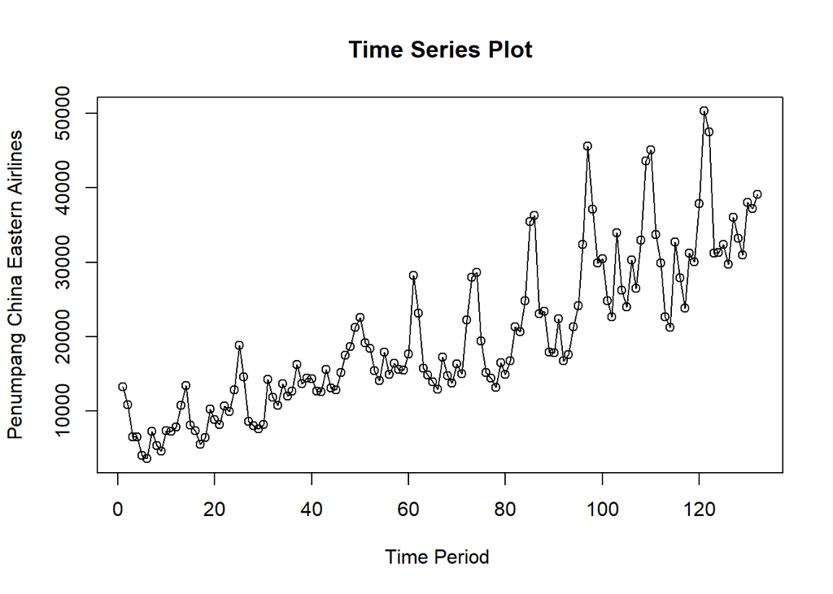

```r
ts.plot(data.ts, xlab="Time Period ", ylab="Penumpang China Eastern Airlines",
        main = "Time Series Plot")
points(data.ts)
```

```r
#menyimpan plot
#dev.copy(png, "eksplorasi.png")
#dev.off()
```

### Eksplorasi Data

Eksplorasi data dilakukan pada keseluruhan data, data latih serta data uji menggunakan plot data deret waktu.

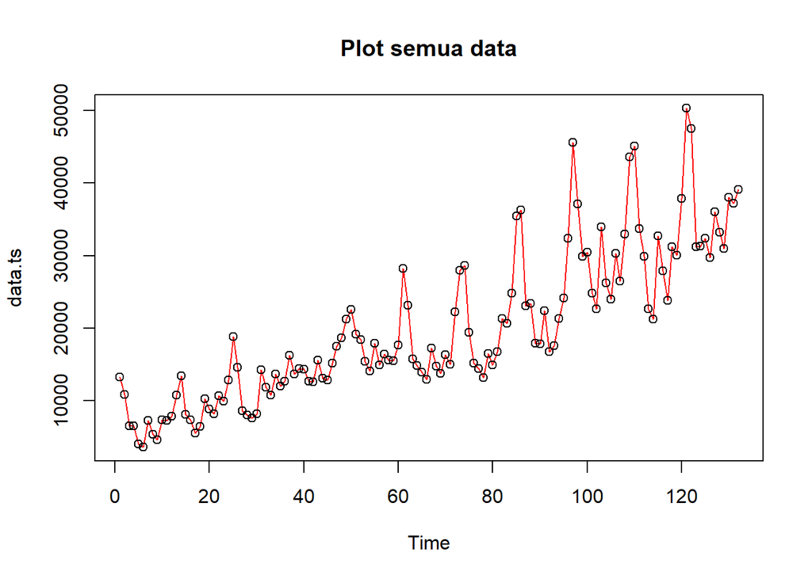

```r
#eksplorasi keseluruhan data
plot(data.ts, col="red",main="Plot semua data")
points(data.ts)
```

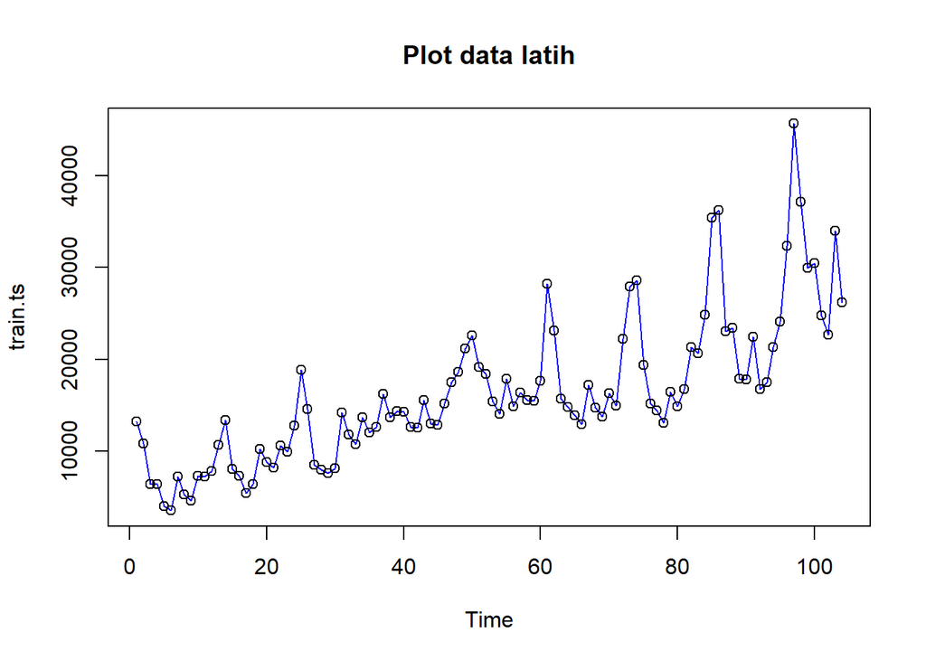

```r
#eksplorasi data latih
plot(train.ts, col="blue",main="Plot data latih")
points(train.ts)
```

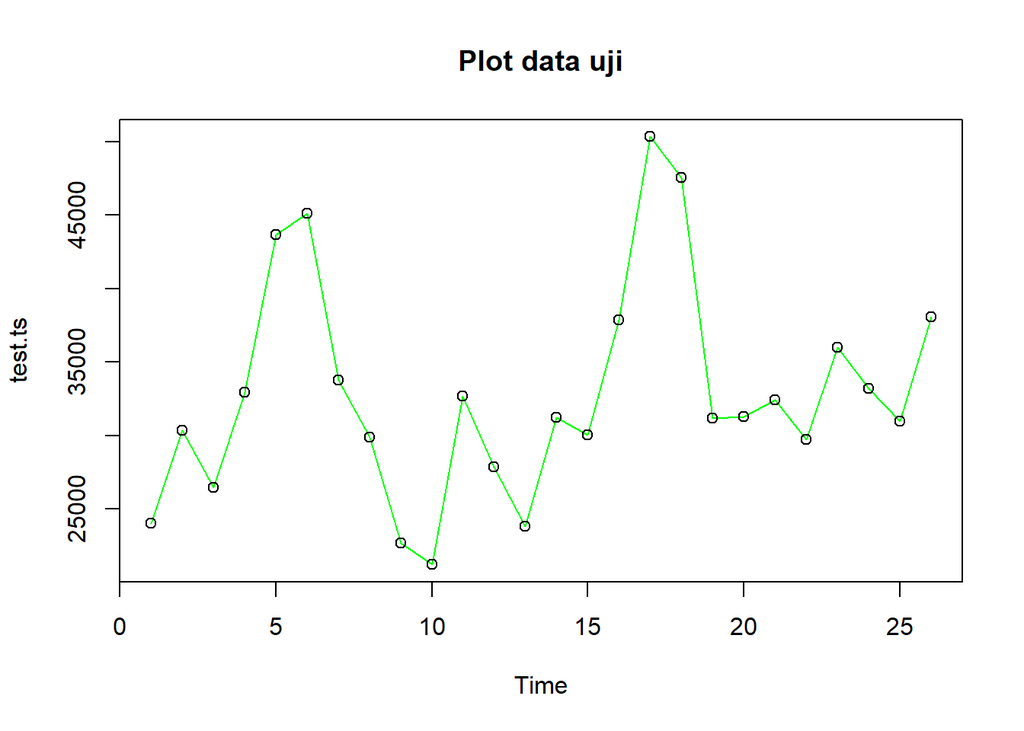

```r
#eksplorasi data uji
plot(test.ts, col="green",main="Plot data uji")
points(test.ts)
```

Eksplorasi data juga dapat dilakukan menggunakan package `ggplot2` dengan terlebih dahulu memanggil library *package* `ggplot2`.

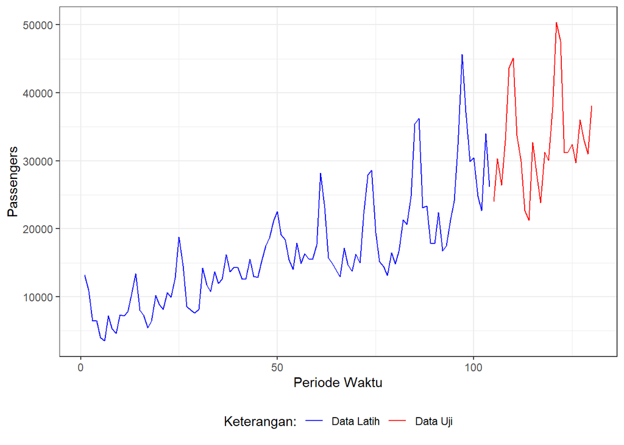

```r
#Eksplorasi dengan GGPLOT
library(ggplot2)
ggplot() +
  geom_line(data = train, aes(x = Month, y = Passengers, col = "Data Latih")) +
  geom_line(data = test, aes(x = Month, y = Passengers, col = "Data Uji")) +
  labs(x = "Periode Waktu", y = "Passengers", color = "Legend") +
  scale_colour_manual(name="Keterangan:", breaks = c("Data Latih", "Data Uji"),
                      values = c("blue", "red")) +
  theme_bw() + theme(legend.position = "bottom",
                     plot.caption = element_text(hjust=0.5, size=12))
```